# PS2_706325626_Writeup

### MGMTMFE 431 - Quantitative Asset Management

### Problem Set 2

### Akhil Srivastava

Link to CRPS data website at WRDS and the risk-parity paper are given below:

- https://wrds-www.wharton.upenn.edu/pages/about/data-vendors/center-for-research-in-security-prices-crsp/
- https://papers.ssrn.com/sol3/papers.cfm?abstract_id=1990493

## Step 1 - Download and save raw CRSP data

- Create a WRDS account to download CRSP data
- Install wrds package in your python environment
- Please refer to following link for sample code for how to connect and download data from WRDS:

  https://wrds-www.wharton.upenn.edu/documents/1443/wrds_connection.html

### Download CRSP stock monthly returns

- Download following fields from the monthly return table “crspq.msf”:

  ```
    permno, permco, date, ret, retx, shrout, prc
  ```

- Download following fields from security names table “crspq.msenames”:

  ```
    permno, date, shrcd, exchcd
  ```

- While running the sql query to download the data use left join on permno and date
- Download full dataset available on WRDS; do not pre-filter by SHRCD, EXCHCD, or date
- Store the downloaded data in pickle format

### Download CRSP stock monthly delisting returns

- Use following fields from the monthly delisting return table “crspq.msedelist”:

  ```
    permno, dlret, dlstdt, dlstcd
  ```

- Store the downloaded data in pickle format

### Download CRSP bonds monthly returns

- Use following fields from the monthly return table “crspq.tfz_mtht”:

  ```
    kycrspid, mcaldt, tmretnua, tmtotout
  ```

- Download full dataset available on WRDS; do not pre-filter by MCALDT
- Store the downloaded data in pickle format

### Download CRSP t-bill monthly returns

- Use following fields from the monthly return table “crspq.mcti”:

  ```
    caldt, t30ret, t90ret
  ```

- Download full dataset available on WRDS; do not pre-filter by caldt
- Store the downloaded data in pickle format

## Step 2 - Process the saved CRSP raw returns

### Process raw CRSP stock returns

- Sometimes there are redundant indices in the downloaded data so sort the data by permno and date and reset the index
- We need to store 'permno', 'permco', 'shrcd', 'exchcd' and 'shrout' columns as integers and nan values lead to exceptions, so drop rows with missing 'shrcd', 'exchcd' and 'shrout' values
- Change the datatype of the above mentioned columns to integer
- Format the date column as datetime
- Again sort the data by permno and date and reset index because we dropped rows above

### Process raw CRSP stock delisting returns

- Sometimes there is redundant indices in the downloaded data so sort the data by permno and 'dlstdt' and reset the index
- Change the datatype of the 'permno' columns to integer
- Rename 'dlstdt' column to ‘date’ and format it as datetime

### Merge CRSP stock returns with the stock delisting returns

- To keep all the values use outer join on date and permno
- Store merged CRSP stock data in pickle format

### Process raw CRSP bond returns

- Sometimes there is redundant indices in the downloaded data so sort the data by kycrspid and mcaldt and reset the index
- Format the mcaldt column as datetime

### Process raw CRSP t-bill returns

- Sometimes there is redundant indices in the downloaded data so sort the data by caldt and reset the index
- Format the caldt column as datetime

## Step 3a – Calculate monthly equal-weighted return, value-weighted return and lagged total market cap. for stocks and bonds

## Stocks

### Filter unrequired data

- Move all the dates to last day of the month
- Again sort the data by permno and date and reset index as we changed date values
- Kenneth R. French uses value-weight return of all CRSP firms incorporated in the US and listed on the NYSE, AMEX, or NASDAQ that have a CRSP share code of 10 or 11
- The above mentioned exchanges have exchange-code (exchcd) 1, 2, 3, 31, 32 and 33, so we need to drop all the other rows
- Similarly, we need to drop the rows which don’t have share-code (shrcd) 10 or 11
- There is a complexity while filtering exchcd/shrcd, exchcd/shrcd are nan for delisted return rows, so filtering rows on required exchcd/shrcd removes all the delisted return rows
- But dlstcd is not-nan for all the delisted return rows, so use it as a proxy to identify delisted return rows and drop unrequired exchcd/shrcd rows only if those are non delisted return rows
- Drop all the rows outside January 1926 to December 2023 timeframe
- Again sort the data by permno and date and reset index because we dropped rows above

### Calculate market equity in USD Millions

- In CRSP data, bid/ask average prices are used as a proxy for trading prices when trading prices are not available but a negative sign is put in front such prices to indicate so
- To handle this use absolute price ('prc') multiplied by outstanding shares ('shrout') to compute market equity and divide it by a thousand to convert it to millions

### Adjust for Delisting Returns

To incorporate delisting returns, we use compounded return if both return and delisted return are available. If any one of them is not available but the other one is, we use the other one i.e.

$ r_{i,t} = \begin{cases} (1 + r_{i,t}^h)(1 + r_{i,t}^d) - 1 \,\,\,if\, both\, r_{i,t}^h\, and\, r_{i,t}^d\, are\, available\\ r_{i,t}^d \,\,\,if\, r_{i,t}^h\, is\, not\, available\\ r_{i,t}^h \,\,\,if\, r_{i,t}^d\, is\, not\, available \end{cases} $

After this if any ret values are still missing we drop them and sort/reset index.

### Find Cumulative Market Cap

A given 'permco' has multiple 'permno', so to find the correct market cap, we use below steps:

- For a given date and permco, we sum market cap ('me') values across different permno to find cumulative market cap for the permco
- For a given date and permco, among multiple market-caps for different permno, we find the largest one
- We merge Merge CRSP_Stocks and CRSP_Stocks_ME_MAX on 'date', 'permco' and 'me' to find correct 'permno'
- Replace market cap ('me') with cumulative market cap
- Sort by permno and date and drop duplicates

### Lagged market cap

- In order to have a portfolio which is not forward looking, we need to use lagged market cap, otherwise it would lead to artifical performance gain. So, at a given time t, we use market cap at t-1.
- If a permno is the first permno, it will have a nan value, so we replace the missing value by me/(1+retx)
- After this is we drop all the rows with missing lagged market cap and reset index

### Data integrity checkes

- CRSP uses missing codes -66, -77, -88 and -99, so make sure none of the returns have these values
- Also, make sure that non of the return or lagged market cap are nan

### Compute required values

- Create 'Year' and 'Month' columns using 'date' and drop 'date' column
- For a given month, we sum across lagged market caps to find lagged total market cap i.e 'Stock_lag_MV' series
- For a given month, we find simple mean of returns to find equal-weighted return i.e. 'Stock_Ew_Ret' series
- For a given month, we find lagged market cap-weighted returns to find value-weighted return i.e 'Stock_Vw_Ret' series

## Bonds

### Filter unrequired data

- Rename columns "kycrspid", "mcaldt", "tmretnua" and "tmtotout" to "crsp_id", "date", "ret" and "me" respectively.
- Move all the dates to last day of the month
- Again sort the data by crsp_id and date and reset index as we changed date values
- Drop all the rows outside January 1926 to December 2023 timeframe
- Drop all the rows with missing return values
- Again sort the data by crsp_id and date and reset index because we dropped rows above

### Lagged market cap

- In order to have a portfolio which is not forward looking, we need to use lagged market cap, otherwise it would lead to artifical performance gain. So, at a given time t, we use market cap at t-1.
- After this is we drop all the rows with missing lagged market cap and sort/reset index

### Data integrity checkes

- CRSP uses missing code -99, so make sure none of the returns have these values
- Also, make sure that non of the return or lagged market cap are nan

### Compute required values

- Create 'Year' and 'Month' columns using 'date' and drop 'date' column
- For a given month, we sum across lagged market caps to find lagged total market cap i.e 'Bond_lag_MV' series
- For a given month, we find simple mean of returns to find equal-weighted return i.e. 'Bond_Ew_Ret' series
- For a given month, we find lagged market cap-weighted returns to find value-weighted return i.e 'Bond_Vw_Ret' series

## Step 3b – Update monthly t-bills (riskless) data to align with stocks and bonds tables

### Filter unrequired data

- Rename columns "caldt", "t30ret" and "t90ret" to "date", "rf30" and "rf90" respectively.
- Move all the dates to last day of the month
- Again sort the data by date and reset index as we changed date values
- Drop all the rows outside January 1926 to December 2023 timeframe
- Drop all the rows with missing return values
- Again sort the data by date and reset index because we dropped rows above

### Data integrity checkes

- Make sure that non of the return values are nan

### Compute required values

- Create 'Year' and 'Month' columns using 'date' and drop 'date' column

## Setp 4 - Aggregate stock, bond and riskless datatables and calculate excess value-weighted returns for both stocks and bonds

- Merge stock, bond, and riskless datatables using 'outer' on 'Year' and 'Month'
- Subtract 'rf30' series from 'Stock_Vw_Ret' and 'Bond_Vw_Ret' to find 'Stock_Excess_Vw_Ret' and 'Bond_Excess_Vw_Ret'
- Drop 'Stock_Ew_Ret', 'Bond_Ew_Ret', 'Stock_Vw_Ret', 'Bond_Vw_Ret', 'rf30' and 'rf90' columns

## Setp 5 - Calculate monthly excess returns for benchmarks and risk-parity portfolios

### Benchmark Portfolios (value-weighted and 60-40)

- For each month, we find excess value-weighted portfolio returns ('Excess_Vw_Ret') by using "Stock_lag_MV" and "Bond_lag_MV" as weights for 'Stock_Excess_Vw_Ret' and 'Bond_Excess_Vw_Ret' respectively
- For each month, we find excess 60-40 portfolio returns ('Excess_60_40_Ret') by using 0.6 and 0.4 as weights for 'Stock_Excess_Vw_Ret' and 'Bond_Excess_Vw_Ret' respectively

### Risk-Parity Portfolios (unlevered and levered)

- For both stocks and bonds compute sigma_hat(t) as the 3-year rolling volatility of their monthly excess returns and take it's reciprocal to compute inverse_sigma_hat
- For each month, calculate inverse_sigma_hat-weighted excess portfolio returns ('port_inv_sigma_wtd_ret') by multiplying 'Stock_Excess_Vw_Ret' and 'Bond_Excess_Vw_Ret' with "Stock_inverse_sigma_hat" and "Bond_inverse_sigma_hat" respectively and taking their sum

### Unlevered Risk-Parity Portfolio

- For each month, compute 'Unlevered_k' by taking reciprocal of the sum of 'Stock_inverse_sigma_hat' and 'Bond_inverse_sigma_hat'
- For each month, compute excess unlevered risk-Parity portfolio returns by multiplying 'port_inv_sigma_wtd_ret' with 'Unlevered_k'

## Setp 6 - Compute performance metrics for all the portfolios

For all the 6 portfolios 'Stock_Excess_Vw_Ret', 'Bond_Excess_Vw_Ret', 'Excess_Vw_Ret', 'Excess_60_40_Ret', 'Excess_Unlevered_RP_Ret' and 'Excess_Levered_RP_Ret':

- Compute montly Mean and Standard Deviation
- Compute annualised Mean and Standard Deviation by multiplying them with 12 and $\sqrt{12}$ repectively
- Compute t-stat of Annualized Mean
- Compute annualised Sharpe Ratio by dividing annualised Mean with annualised Standard Deviation
- Compute Skewness and Excess Kurtosis

### Replication Result

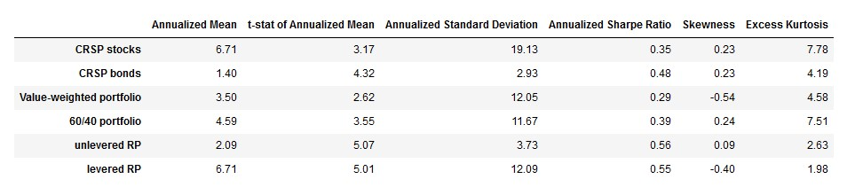

### Asness, Frazzini, and Pedersen (2012) - Table 2 - Historical Performance

| Portfolio | Annualized Mean | t-stat of Annualized Mean | Annualized Standard Deviation | Annualized Sharpe Ratio | Skewness | Excess Kurtosis |
| --- | --- | --- | --- | --- | --- | --- |
| CRSP stocks | 6.71 | 3.18 | 19.05 | 0.35 | 0.18 | 7.51 |
| CRSP bonds | 1.56 | 4.28 | 3.28 | 0.47 | -0.01 | 4.37 |
| Value-weighted portfolio | 3.84 | 2.30 | 15.08 | 0.25 | 0.37 | 13.09 |
| 60/40 portfolio | 4.65 | 3.59 | 11.68 | 0.40 | 0.20 | 7.46 |
| unlevered RP | 2.20 | 4.67 | 4.25 | 0.52 | 0.05 | 4.58 |
| levered RP | 7.99 | 4.78 | 15.08 | 0.53 | -0.36 | 1.92 |

### Percent Difference of Replication Result from Asness, Frazzini, and Pedersen (2012)

[output not shown]

As we can see, percent deviation in values are economically negligible for CRSP Stocks and 60/40 portfolios but significant for other portfolios.

We made a lot of different choices during the replication and we do not have the information about how Asness, Frazzini, and Pedersen (2012), so the discrepancy could be because of those reasons.

All such choices are listed below:

**Stocks Data**

- Dropped missing 'shrcd', 'exchcd' and 'shrout'
- 'outer' join for merging non-desliting returns with delisted returns
- Used a specific way to handle delisting return conflict while filtering exchcd/shrcd
- Delisting return handling
- Missing return handling
- Replacing negative price ('prc') with it's absolute values, while computing market cap
- Handling of 'permno' and 'permco' to find market-cap
- Handling of missing lagged market-cap values
- Other joining choices we made while merging dataframes
- How delisting reason was used to modify returns
- Different operations affect each other, so sequencing of these steps e.g. swapping return and lagged market cap handling produce slightly different results

**Bonds Data**

- Missing return handling
- Handling of missing lagged market-cap values
- Different operations affect each other, so sequencing of these steps

**T-Bills Data**

- Missing return handling

**Risk Parity Calculations**

- As portfolio weights in case of risk parity portfolios are particularly sensitive to rolling volatilities, error in volatility estimation is especially harmful in these cases
- Perhaps that is the reason why risk parity portfolio replication is not as good as others